# Edit tables in a relational database - dm package

2025-01-31

If it is your first time using `editbl`, make sure to first read the introductory vignette on how to work with relational databases (`vignette("howto_relational_db")`).

This document describes how make use of the [{dm} package](https://CRAN.R-project.org/package=dm). This package is useful to extract relational data models out of a database into R. Which can help in setting up a correct configuration for `editbl`.

```r
library(dplyr)
library(shiny)
library(editbl)
library(dm)
```

## Creating a database connection

The first thing you need is a database connection. Here we connect to an [sqlite](https://en.wikipedia.org/wiki/SQLite) file, which is a portable database format.

```r
tmpFile <- tempfile(fileext = ".sqlite")
file.copy(system.file("extdata", "chinook.sqlite", package = 'editbl'), tmpFile)
conn <-   DBI::dbConnect(
    dbname = tmpFile,
    drv = RSQLite::SQLite()
)
```

## Setting up the data model

```r
dm <- dm::dm_from_con(conn, learn_keys = FALSE)
```

For some databases this is all you need to do. Currently `dm` can not (yet) learn the keys from SQLite. Thus we still manually have to specify the primary and foreign keys.

```r
dm <- dm %>%
    dm_add_pk(Artist, ArtistId) %>%
    dm_add_pk(Album, AlbumId) %>%
    dm_add_pk(Customer, CustomerId) %>%
    dm_add_pk(Employee, EmployeeId) %>%
    dm_add_pk(Genre, GenreId) %>%
    dm_add_pk(Invoice, InvoiceId) %>%
    dm_add_pk(InvoiceLine, InvoiceLineId) %>%
    dm_add_pk(MediaType, MediaTypeId) %>%
    dm_add_pk(Playlist, PlaylistId) %>%
    dm_add_pk(PlaylistTrack, c(PlaylistId, TrackId)) %>%
    dm_add_pk(Track, TrackId)
```

```r
dm <- dm %>%
    dm_add_fk(
      table = Album,
      columns = ArtistId,
      ref_table = Artist) %>%
    dm_add_fk(
      table = Invoice,
      columns = CustomerId,
      ref_table = Customer) %>%
    dm_add_fk(
      table = InvoiceLine,
      columns = InvoiceId,
      ref_table = Invoice) %>%
    dm_add_fk(
      table = InvoiceLine,
      columns = TrackId,
      ref_table = Track) %>%
    dm_add_fk(
      table = PlaylistTrack,
      columns = TrackId,
      ref_table = Track) %>%
    dm_add_fk(
      table = PlaylistTrack,
      columns = PlaylistId,
      ref_table = Playlist) %>%
    dm_add_fk(
      table = Track,
      columns = AlbumId,
      ref_table = Album) %>%
    dm_add_fk(
      table = Track,
      columns = MediaTypeId,
      ref_table = MediaType) %>%
    dm_add_fk(
      table = Track,
      columns = GenreId,
      ref_table = Genre)
```

## Fully fletched table editor

A relational database consists out of many normalized tables. This is a perfect model for storing data, since it avoids duplicate information. However, it often leads to rather incomprehensible tables with a lot of ‘id’ columns. The goal of this editor is therefore to give people the opportunity to edit a table in its ‘flat’ form. Meaning you join all tables with additional information based on these ‘id’ keys. See also this function of `dm`:

```r
dm::dm_flatten_to_tbl(dm, "Album", .recursive = TRUE)
```

```
## # Source:   SQL [?? x 4]
## # Database: sqlite 3.45.0 [/tmp/RtmpCc5ZGd/filef2bb332bd9e1e.sqlite]
##    AlbumId Title                                 ArtistId Name
##      <int> <chr>                                    <int> <chr>
##  1       1 For Those About To Rock We Salute You        1 AC/DC
##  2       2 Balls to the Wall                            2 Accept
##  3       3 Restless and Wild                            2 Accept
##  4       4 Let There Be Rock                            1 AC/DC
##  5       5 Big Ones                                     3 Aerosmith
##  6       6 Jagged Little Pill                           4 Alanis Morissette
##  7       7 Facelift                                     5 Alice In Chains
##  8       8 Warner 25 Anos                               6 Antônio Carlos Jobim
##  9       9 Plays Metallica By Four Cellos               7 Apocalyptica
## 10      10 Audioslave                                   8 Audioslave
## # ℹ more rows
```

As you can see, providing the `ArtistName` to a user is way more convenient than just the `ArtistId`.

`editbl::eDT` can handle similar joins by its `foreignTbls` argument. Let us define a function that extracts the needed information from a `dm` object.

```r
getForeignTbls <- function(dm, table){
  dm_fks <- dm::dm_get_all_fks(dm)
  dm_fks <- dm_fks[dm_fks$child_table == table,]
  tbl_list <- dm::dm_get_tables(dm)

  foreignTbls <- lapply(seq_len(nrow(dm_fks)), function(i){
      r <- dm_fks[i,]
      x <- tbl_list[r$child_table][[1]]
      y <- dm::dm_flatten_to_tbl(dm, !!(r$parent_table), .recursive = TRUE)

      child_fks <- unlist(r$child_fk_cols)
      parent_fks <- unlist(r$parent_key_cols)

      # Renaming of parent colums to avoid naming conflicts
      # Done a bit heuristically here for convenience.
      lookup <- parent_fks
      names(lookup) <- child_fks
      other_parent_cols <- setdiff(colnames(y), parent_fks)
      names(other_parent_cols) <- paste(r$parent_table, other_parent_cols, sep = '.')
      lookup <- c(lookup, other_parent_cols)
      y <- y %>% dplyr::rename(all_of(lookup))

      editbl::foreignTbl(
        x = x,
        y = y,
        by = child_fks,
        naturalKey = colnames(y)
    )

  })
  foreignTbls
  }
```

Next, let’s use this to build a shiny app.

```r
dbUI <- function(id) {
  ns <- NS(id)
  fluidPage(
      uiOutput(outputId = ns('selectUI')),
      eDTOutput(id = ns('DT'))
  )
}

dbServer <- function(id, dm) {
  moduleServer(
      id,
      function(input, output, session) {
        ns <- session$ns

        tables <- dm::dm_get_tables(dm)

        output$selectUI <- renderUI({
          selectInput(ns('table'), label = 'table', choices = names(tables))
        })

        data <- reactive({
              req(input$table)
              tables[input$table][[1]]
              })

        foreignTbls <-  reactive({
              req(input$table)
              getForeignTbls(dm, input$table)
              })

        eDT(
            id = "DT",
            data = data,
            foreignTbls = foreignTbls,
            in_place = TRUE
        )

        invisible()
      }
  )
}
```

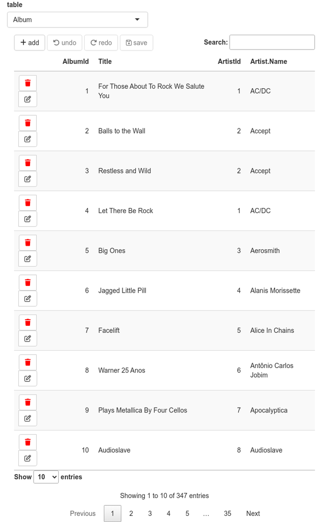

```r
shiny::shinyApp(
    ui = dbUI('id'),
    server =  function(input, output,session){
      dbServer('id', dm)
    })
```

As you click the ‘edit’ button, you will notice you can now select rows from the referenced tables. This makes it easier to navigate compared to just having id’s to work with.